# Regression Project.Rmd

Harold Trammel

September 7, 2015

## *Motor Trend* Car Road Tests

### Introduction

*Motor Trend* is interested in exploring the relationship between a set of variables and miles per gallon (MPG) (outcome). They have provided a set of data from automobiles that they tested over a period of time. They are particularly interested in the following two questions:

- “Is an automatic or manual transmission better for MPG”
- “Quantify the MPG difference between automatic and manual transmissions”

A modern automobile is a complex machine and as such no one component is fully responsible for its performance and efficiency. Some of the car_df in the sample have been designed for performance while others were designed for performance or luxury. This inherent complexity must be kept in mind when looking a single complonent such as the type of transmission.

### General Exploration

The data that *Motor Trend* provided was eleven different measured collected from 32 different automobiles. Three of the variables (Miles Per Gallon, Gross Horsepower, and 1/4 Mile Time) are dependent on different sets of the other variables. Some of the variables are factors even though their values are numeric. These are: Number of Cylinders, Vee vs Straight Cylinder Arrangement, Transmission Type, Number of Forward Gears, and Number of Carburators. Displacement, Rear Axle Ratio, and Weight are continous variables.

### Focused Analysis

I compared the statistics related to milage recorded in car_df with automatic transmissions to those with manual. The mean milage in automatic car_df was 17.1474 ± 0.8796 (std. error of mean) with a standard deviation of 3.834. For manual transmission car_df, the mean milage 24.3923 ± 1.7103 (std. error of mean) with a standard deviation of 6.1665.

### Appendix

Table 1 Correlation of Mileage and All Other Variables

|  | mpg |
| --- | --- |
| mpg | 1.0000 |
| cyl | -0.8522 |
| disp | -0.8476 |
| hp | -0.7762 |
| drat | 0.6812 |
| wt | -0.8677 |
| qsec | 0.4187 |
| vs | 0.6640 |
| am | 0.5998 |
| gear | 0.4803 |
| carb | -0.5509 |

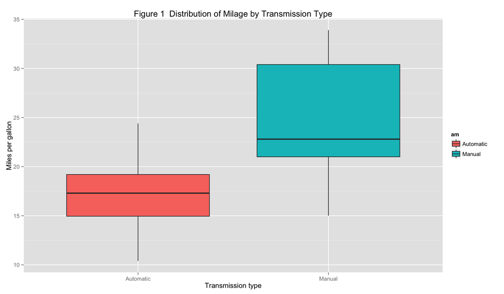

All Fit Coefficients

|  | Estimate | Std. Error | t value | Pr(>\|t\|) |
| --- | --- | --- | --- | --- |
| (Intercept) | 23.8791 | 20.0658 | 1.1900 | 0.2525 |
| cyl6 | -2.6487 | 3.0409 | -0.8710 | 0.3975 |
| cyl8 | -0.3362 | 7.1595 | -0.0470 | 0.9632 |
| disp | 0.0355 | 0.0319 | 1.1143 | 0.2827 |
| hp | -0.0705 | 0.0394 | -1.7884 | 0.0939 |
| drat | 1.1828 | 2.4835 | 0.4763 | 0.6407 |
| wt | -4.5298 | 2.5387 | -1.7843 | 0.0946 |
| qsec | 0.3678 | 0.9354 | 0.3933 | 0.6997 |
| vsStraight | 1.9309 | 2.8713 | 0.6725 | 0.5115 |
| amManual | 1.2121 | 3.2135 | 0.3772 | 0.7113 |
| gear4 | 1.1144 | 3.7995 | 0.2933 | 0.7733 |
| gear5 | 2.5284 | 3.7364 | 0.6767 | 0.5089 |
| carb2 | -0.9794 | 2.3180 | -0.4225 | 0.6787 |
| carb3 | 2.9996 | 4.2935 | 0.6986 | 0.4955 |
| carb4 | 1.0914 | 4.4496 | 0.2453 | 0.8096 |
| carb6 | 4.4776 | 6.3841 | 0.7014 | 0.4938 |
| carb8 | 7.2504 | 8.3606 | 0.8672 | 0.3995 |

Milage to Weight, Displacement, Horsepower, and Rear-Axle Ratio Coefficients

|  | Estimate | Std. Error | t value | Pr(>\|t\|) |
| --- | --- | --- | --- | --- |
| (Intercept) | 29.1487 | 6.2936 | 4.6315 | 0.0001 |
| wt | -3.4797 | 1.0784 | -3.2268 | 0.0033 |
| disp | 0.0038 | 0.0108 | 0.3531 | 0.7268 |
| hp | -0.0348 | 0.0116 | -2.9993 | 0.0058 |
| drat | 1.7680 | 1.3198 | 1.3397 | 0.1915 |

Milage to Transmission Type, Gear Count, Cylinder Count, Carburator Count and Cylinder Arrangment Coefficients

|  | Estimate | Std. Error | t value | Pr(>\|t\|) |
| --- | --- | --- | --- | --- |
| (Intercept) | 21.7355 | 3.755 | 5.7882 | 0.0000 |
| amManual | 3.3568 | 2.592 | 1.2948 | 0.2101 |
| gear4 | 2.7244 | 3.201 | 0.8512 | 0.4047 |
| gear5 | 2.5226 | 3.812 | 0.6618 | 0.5157 |
| cyl6 | -1.8215 | 2.303 | -0.7909 | 0.4383 |
| cyl8 | -3.9916 | 3.635 | -1.0980 | 0.2852 |
| vsStraight | 0.6528 | 2.814 | 0.2320 | 0.8189 |
| carb2 | -1.0023 | 2.290 | -0.4377 | 0.6663 |
| carb3 | -1.4439 | 3.151 | -0.4583 | 0.6517 |
| carb4 | -5.3016 | 2.922 | -1.8141 | 0.0847 |
| carb6 | -6.0934 | 4.856 | -1.2549 | 0.2240 |
| carb8 | -8.6234 | 5.223 | -1.6511 | 0.1143 |

Automatic vs Manual Coefficients

|  | Estimate | Std. Error | t value | Pr(>\|t\|) |
| --- | --- | --- | --- | --- |
| (Intercept) | 17.147 | 1.125 | 15.248 | 0.0000 |
| amManual | 7.245 | 1.764 | 4.106 | 0.0003 |

#### Reference

```
A data frame with 32 observations on 11 variables.
[, 1]   mpg     Miles/(US) gallon
[, 2]   cyl     Number of cylinders
[, 3]   disp    Displacement (cu.in.)
[, 4]   hp      Gross horsepower
[, 5]   drat    Rear axle ratio
[, 6]   wt      Weight (lb/1000)
[, 7]   qsec    1/4 mile time
[, 8]   vs      Vee vs Straight Cylinder Arrangement
[, 9]   am      Transmission (0 = automatic, 1 = manual)
[,10]   gear    Number of forward gears
[,11]   carb    Number of carburetors
```

Evaluation Criteria

- Did the student interpret the coefficients correctly?
- Did the student do some exploratory data analyses?
- Did the student fit multiple models and detail their strategy for model selection?
- Did the student answer the questions of interest or detail why the question(s) is (are) not answerable?
- Did the student do a residual plot and some diagnostics?
- Did the student quantify the uncertainty in their conclusions and/or perform an inference correctly?
- Was the report brief (about 2 pages long) for the main body of the report and no longer than 5 with supporting appendix of figures?
- Did the report include an executive summary?
- Was the report done in Rmd (knitr)?